# Breast Cancer prediction using Naive Bayes Classifier

Karina Pizano

5/8/2017

```r
library(e1071)
library(rpart)
source("/Users/karinapizano/Documents/Data Mining/lin-regr-util.R")
source("/Users/karinapizano/Documents/Data Mining/class-util.R")
```

### Breast Cancer Prediction

*Data Cleaning and Munging*

```r
dat = read.csv("data.csv")

# Create Factors
dat$diagnosis = factor(dat$diagnosis, labels =c("None", "Cancer"))

# Part the data.
data_sets = split_data(dat)
tr_dat = data_sets[[1]]
te_dat = data_sets[[2]]

# Remove bad columns and data.
dat$X = NULL
```

## Data Exploration

*Scatter Plot to detect any correlation between the attributes.*

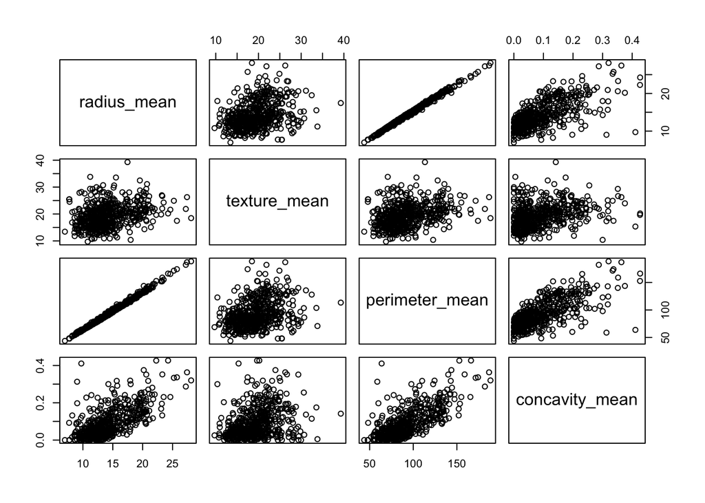

```r
plot(dat[,c("radius_mean", "texture_mean","perimeter_mean", "concavity_mean")])
```

*We can see more correlation between more attributes*

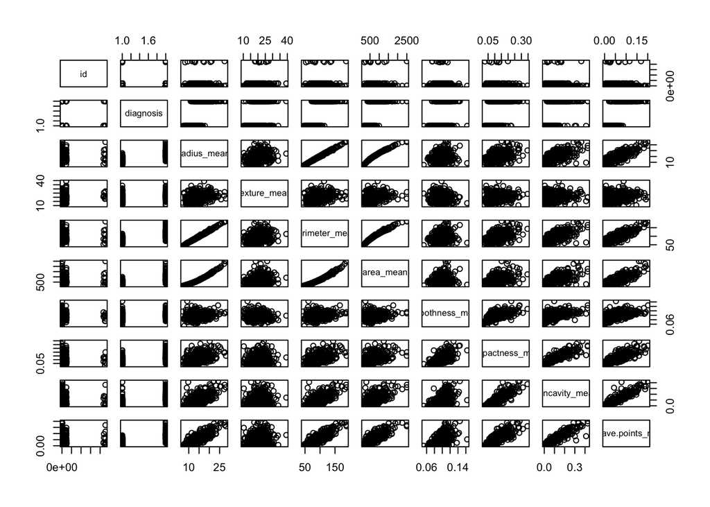

```r
plot(dat[,1:10])
```

*Our data contains a good balance of diagnosis data.*

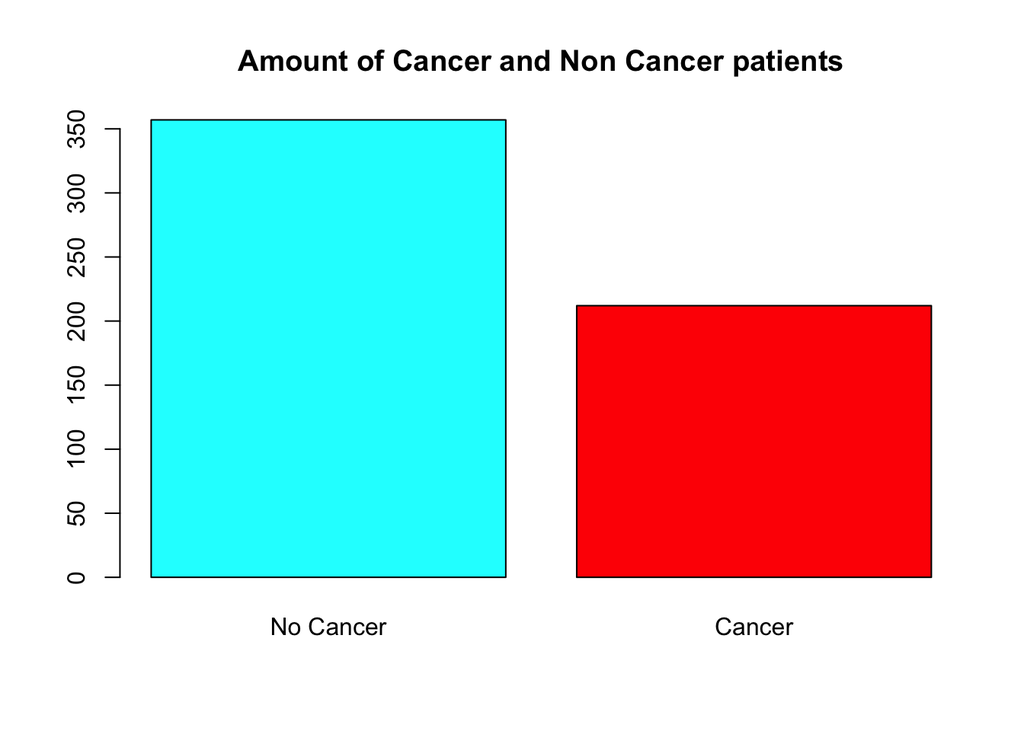

```r
barplot(table(dat$diagnosis), names.arg=c("No Cancer", "Cancer"), main="Amount of Cancer and Non Cancer patients", col=c("cyan", "red"))
```

*Whats a popular radius mean when looking at an infected area?*

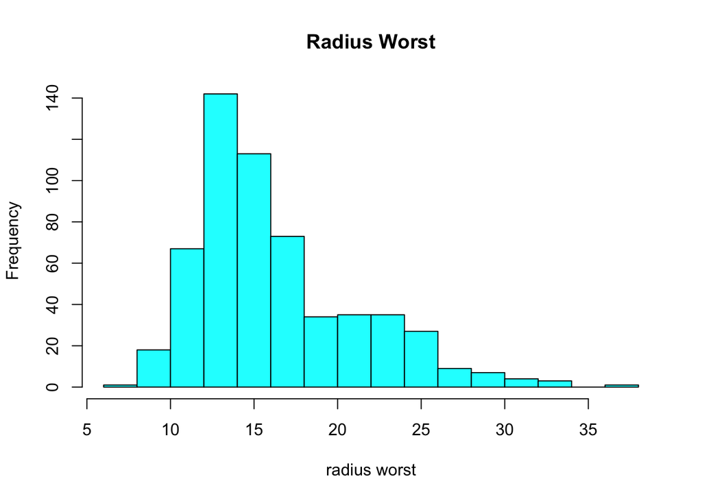

```r
hist(dat$radius_worst, main="Radius Worst", col="cyan", xlab = "radius worst")
```

## Naive Bayes Model

*Create a Naive Bayes Model*

```r
fit = naiveBayes(diagnosis ~ radius_worst + texture_worst + concave.points_worst, data= tr_dat)
```

*Summary of the Model*

```r
summary(fit)
```

```
##         Length Class  Mode
## apriori 2      table  numeric
## tables  3      -none- list
## levels  2      -none- character
## call    4      -none- call
```

*Predictions & Confusion Matrix*

```r
predictions = predict(fit, newdata=te_dat)
con_matrix = table(te_dat$diagnosis, predictions)
con_matrix
```

```
##         predictions
##          None Cancer
##   None     83      1
##   Cancer    2     57
```

*The accuracy of our classifier.*

```r
accuracy = mean(predictions == te_dat$diagnosis)
accuracy
```

```
## [1] 0.979021
```

*Precision of the Classifier*

```r
con_matrix[2,2] / (con_matrix[2,2] + con_matrix[1,2])
```

```
## [1] 0.9827586
```

*Recall of our Classifier*

```r
con_matrix[2,2] / (con_matrix[2,2] + con_matrix[2,1])
```

```
## [1] 0.9661017
```

*Showing the distribution of radius worst when a person is diagnosed with cancer or not diagnosed with the cancer using radius worst. We can see that as the radius worst increases above 15 the changes are higher of being diagnosed with cancer.*

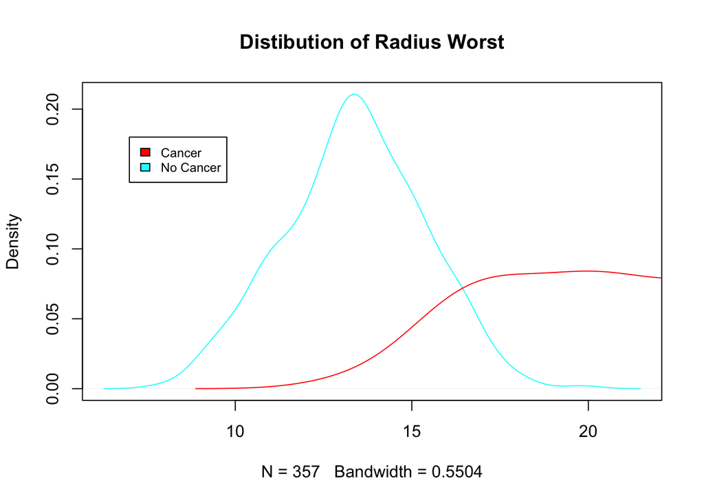

```r
plot(density(dat[dat$diagnosis == "None",]$radius_worst), col="cyan", main="Distibution of Radius Worst")
lines(density(dat[dat$diagnosis == "Cancer",]$radius_worst), col="red")
legend(7,0.18,legend =c("Cancer", "No Cancer"), fill=c("red", "cyan"), cex=0.75)
```

*We are looking at the trained distributions for the fitted model, both when the disease IS present and NOT present. Mean and Standard Deviation.*

```r
fit$tables$radius_worst
```

```
##         radius_worst
## Y            [,1]     [,2]
##   None   13.38222 1.953529
##   Cancer 21.33641 4.300359
```

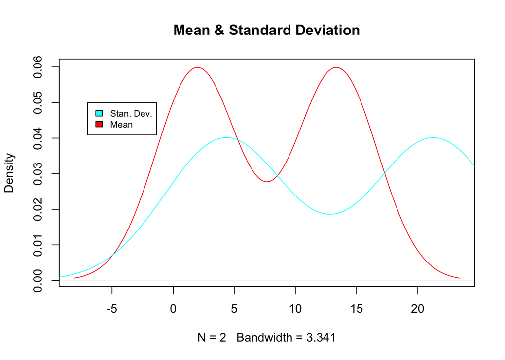

```r
plot(density(fit$tables$radius_worst[1,]), col="red", main="Mean & Standard Deviation")
lines(density(fit$tables$radius_worst[2,]), col="cyan")
legend(-7,0.05,legend =c("Stan. Dev.", "Mean"), fill=c("cyan", "red"), cex=0.75)
```

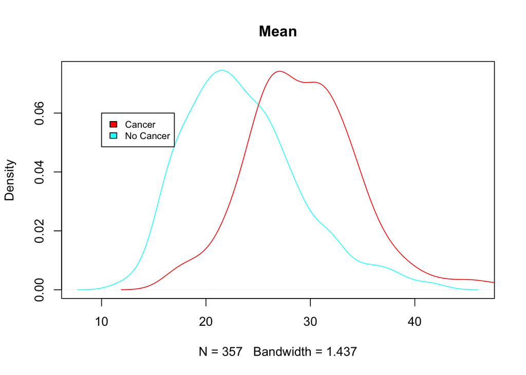

```r
plot(density(dat[dat$diagnosis == "None",]$texture_worst), col="cyan", main="Mean")
lines(density(dat[dat$diagnosis == "Cancer",]$texture_worst), col="red")
legend(10,0.06,legend =c("Cancer", "No Cancer"), fill=c("red", "cyan"), cex=0.75)
```

*Let’s see how good we are able to predict Breast Cancer using naive bayes conditional probability and then compare it to the e01171 predictor.*

```r
#Computing features.
tb = te_dat[1, c("radius_worst", "texture_worst", "concave.points_worst")]

#Compute P(radius_mean | no disease) and p(radius_mean | disease)
prob_no_radius_disease = dnorm(tb$radius_worst,mean=fit$tables$radius_worst[1,1],sd=fit$tables$radius_worst[1,2])
prob_yes_radius_disease = dnorm(tb$radius_worst,mean=fit$tables$radius_worst[2,1],sd=fit$tables$radius_worst[2,2])

#Compute P(texture_worst | no disease) and P(texture_worst | disease)
prob_no_text_disease = dnorm(tb$texture_worst,mean=fit$tables$texture_worst[1,1],sd=fit$tables$texture_worst[1,2])
prob_yes_text_disease = dnorm(tb$texture_worst,mean=fit$tables$texture_worst[2,1],sd=fit$tables$texture_worst[2,2])

#Compute P(concave.points_worst | no disease) and P(concave.points_worst | disease)
prob_no_points_disease = dnorm(tb$concave.points_worst,mean=fit$tables$concave.points_worst[1,1],sd=fit$tables$concave.points_worst[1,2])
prob_yes_points_disease = dnorm(tb$concave.points_worst,mean=fit$tables$concave.points_worst[2,1],sd=fit$tables$concave.points_worst[2,2])

#Probabilities of disease and no disease.
prob_no_disease = fit$apriori[1]
prob_yes_disease = fit$apriori[2]

output = ((prob_no_radius_disease * prob_no_text_disease * prob_no_points_disease * prob_no_disease) / (prob_yes_radius_disease * prob_yes_text_disease * prob_yes_points_disease * prob_yes_disease))
output
```

```
##     None
## 235.7748
```

*Our prediction tells us ..*

```r
pred = ifelse(output > 1, "No Cancer", "Cancer")
pred
```

```
##        None
## "No Cancer"
```

*The e01071 says*

```r
predict(fit, newdata = tb)
```

```
## [1] None
## Levels: None Cancer
```

## Learning Curve for Naive Bayes Classifier

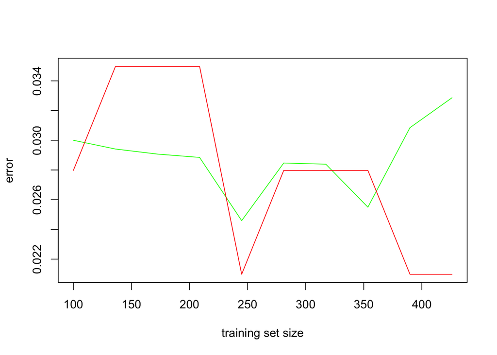

```r
te_errs = c()
tr_errs = c()
te_actual = te_dat$diagnosis
tr_sizes = seq(100, nrow(tr_dat), length.out=10)

for (tr_size in tr_sizes) {
  tr_dat1 = tr_dat[1:tr_size,]
  tr_actual = tr_dat1$diagnosis
  fit = naiveBayes(diagnosis ~ radius_worst + texture_worst + concave.points_worst, data=tr_dat1)

  # error on training set
  tr_predicted = predict(fit, tr_dat1, type="class")
  tr_predicted
  err = sum(tr_actual != tr_predicted)/length(tr_predicted)
  tr_errs = c(tr_errs, err)

  # error on test set
  te_predicted = predict(fit, te_dat, type="class")
  err = sum(te_actual != te_predicted)/length(te_predicted)
  te_errs = c(te_errs, err)
  te_errs
}

plot(range(tr_sizes), range(te_errs, tr_errs), type='n', xlab='training set size', ylab='error')

lines(tr_sizes, tr_errs, col='green')
lines(tr_sizes, te_errs, col='red')
```